# Test 4

Librerías

```r
library(rvest)
library(tidyverse)
library(ggplot2)
library(knitr)
library(tm)
library(stringi)
library(sentiment)
library(wordcloud)
library(sentiment)
library(tm)
library(quanteda)
```

Leemos la lista inicial de hinchadas argentinas disponibles

```r
#pagina <- read_html("https://barrabrava.net/pais/argentina/")
```

Saco las URL de cada una de las barras. Para esto leo los nodos con hipervínculos y saco los que van hacia cada club.

```r
#listaurlbarras <- pagina %>% html_nodes("table")%>% html_nodes("tr") %>% html_nodes("a") %>% html_attr("href")
#listaurlbarras <- listaurlbarras[!str_detect(listaurlbarras, "/club/")]
```

Leemos y armamos la lista de las URLs con las letras.

```r
# listaurlletras <- list()
#
# for(i in listaurlbarras){
#   direccion <- paste0("https://barrabrava.net",i,"letras")
#   pagina <- read_html(direccion)
#   listaurltmp <- pagina %>% html_nodes("section") %>% html_nodes("a") %>% html_attr("href")
#   listaurlletras <- c(listaurlletras, listaurltmp)
# }
# listaurlletras <- unlist(listaurlletras)
# listaurlletras <- listaurlletras[!str_detect(listaurlletras, "usuario")]
```

Con estas URLs armo finalmente la lista de letras.

```r
#listaletras <- list()
#listaletrastmp <- list()
#for(i in listaurlletras){
#  direccion <- paste0("https://barrabrava.net",i)
#  cat("leyendo direccion ", direccion, "\n")
#  pagina <- read_html(direccion)
#  listaletrastmp <- pagina %>% html_nodes("p") %>% as.character() %>% str_replace_all("<br>", " ") %>%
#  listaletras <- c(listaletras, listaletrastmp[2])
#}

#listaletras <- unlist(listaletras)
```

Armo el dataframe de letras con los datos de cada una.

```r
# df_letras <- data.frame(listaurlletras)
# df_letras$listaurlletras <- df_letras$listaurlletras %>% str_replace_all("-", " ")
# df_letras <- separate(data = df_letras, col = listaurlletras, into = c("uno","club", "barra", "dos", "titulo"), sep = "/")
# df_letras$uno <- NULL
# df_letras$dos <- NULL
# df_letras$letra <- listaletras %>% str_replace_all(","," ") %>% str_replace_all(";"," ") %>% str_replace_all("  "," ") %>% tolower()
# df_letras <- df_letras %>% filter(letra != "")
```

Como ya lo tenía en un archivo levanto el scrap de ahí.

```r
df_letras <- read.csv("letrasbarras.csv", sep = ";", stringsAsFactors = FALSE)
```

Limpio las letras

```r
df_letras$letra_clean <- str_replace_all(df_letras$Letra, "(\\w)(\\1{2,})", "\\1")
df_letras$letra_clean <- str_replace_all(df_letras$letra_clean, "[^a-z,á,é,í,ó,ú,0-9\\s]", "")
df_letras$letra_clean <- str_replace_all(df_letras$letra_clean, "  ", " ")
```

Genero los tokens

```r
armar_tokens <- function(string1){
    temp <- stringr::str_split(string1, " ")
    temp <- lapply(temp, unique)
    return(temp)
}

df_letras$tokens_clean <- armar_tokens(df_letras$letra_clean)
```

Genero la columna de texto “limpio”

```r
df_letras$text_clean <- ifelse(unlist(lapply(df_letras$tokens_clean, length)) == 0," ", stri_paste_list(df_letras$tokens_clean, sep = " "))
df_letras$text <- df_letras$text_clean
```

Armo el corpus y veo que asocia a cada barra. Todavía falta limpiar stopwords pero da una idea de para donde va.

```r
corpusdatos <- corpus(df_letras)
dfm_datos <- dfm(corpusdatos)
tokensporbarra <- topfeatures(dfm_datos, 5, groups = "Club")
tokensporbarra
```

```
## $aldosivi
##  la que   a  de  te
##  16  14  14  12  11
##
## $`all boys`
##       de        a       no floresta       la
##       12       11       10       10        9
##
## $almagro
##       y       a      de almagro     que
##       4       4       3       3       2
##
## $`almirante brown`
##   que    el     a    la banda
##     5     4     4     4     4
##
## $alvarado
##     a    la   que    el brava
##     9     9     7     7     7
##
## $`argentino de quilmes`
##   y  la que los  de
##   5   5   4   4   4
##
## $`argentinos juniors`
## que   y   a  la  no
##   5   5   5   5   4
##
## $atlanta
##  no   a  lo  de que
##   6   6   5   5   4
##
## $`atletico platense`
##   a  en  la que   y
##   7   6   6   5   5
##
## $`atletico tucuman`
##  de que   a  la  te
##   7   6   6   6   6
##
```

[output cut: 172 more lines]

```
## $`union de santa fe`
##  y  a la te de
##  8  8  7  7  6
##
## $`velez sarsfield`
##   a  la  de que  te
##  54  46  46  39  39
##
## $`villa mitre`
## que los   a  la  de
##   4   4   4   4   4
##
## $yupanqui
## que los  el  no vos
##   1   1   1   1   1
```

Armo un corpus limpio

```r
corpus_letras_clean <- Corpus(VectorSource(df_letras$letra_clean))
corpus_letras_limpio_c2 <- tm_map(corpus_letras_clean, removeNumbers)
corpus_letras_limpio_c2 <- tm_map(corpus_letras_limpio_c2, removePunctuation)
corpus_letras_limpio_c2 <- tm_map(corpus_letras_limpio_c2, stripWhitespace)
corpus_letras_limpio_c2 <- tm_map(corpus_letras_limpio_c2, removeWords, stopwords(language = "es"))
inspect(corpus_letras_limpio_c2[1:10])
```

```
## <<SimpleCorpus>>
## Metadata:  corpus specific: 1, document level (indexed): 0
## Content:  documents: 10
##
##  [1] aun    campeones  rojo   demonstró  sentimiento  cambia vos sos amargo  cagón siempre    malas  buenas  van  venir  racing  hace grande  gente  vos  existis ooh oh
##  [2] aca   gloriosa banda   academia   va  todas partes   siempre  alienta  pesar   aos  momentos vividos siempre estare   lado racing racing querido racing racing querido
##  [3] academia  llevo   corazon  cualquier cancha  juegues voy  vos   importa si perdes  si ganas academia cada ves  quiero mas vamo acade vamo  ganar avellaneda  carnaval  jugues  voy      guardia imperial
##  [4]    numero    sigue  todas partes siempre   estandartes   grito  corazón racing campeón racing campeón      oeste   norte    sur brillara blanca  celeste  academia racing club   acade   acade
##  [5] nadie comprende   venga  alentarte cada día  pasa  amor  vos  mas grande racing  lleva   alma  puede dejarse   voy  quedar   cancha solo pa alentarte
##  [6]  alegria  alegria ole ole ola vamos racing todavia    ganar   hinchada loca seguro     sigue  todas partes  alienta   final  tenemo aguante aguante  verdad   numero    guardia imperial
##  [7]  pendejo  sigo junto  racing siempre   lados  bancamos  quiebra  descenso   alquilados   olvido  día   vieja chiflada decía  racing  existía    ser liquidado si llenamos  cancha   jugamos ohoo ohoo defendimos  remate  sede ohoo ohoo si     hinchada diferente   amarga    independiente ohoo oh…
##  [8] academia  llevo   corazon  cualquier cancha  juegues voy  vos   importa si perdes  si ganas  academia cada vez  quiero mas vamo acade vamo  ganar avellaneda  carnaval  jugues  voy      guardia imperial
##  [9]   gritar seor   gritar   gritar seor   gritar   gritar seor   gritar  vamos vamos racing    ganar
## [10]  cancha  cemento   vas  tener  alla   bajo flores vas  correr tambien   cambia  vas  morir cagon  dice  academia  siempre  corrio  alegria  alegria ole ole ola vamos racing todabia    ganar
```

De acá en adelante armo el term document matrix (tdm), el document term matrix (dtm)

```r
tdm_letras_c2 <- TermDocumentMatrix(corpus_letras_limpio_c2, control = list(stopwords = FALSE))
tdm_letras_c2 <- as.matrix(tdm_letras_c2)
dtm_letras_c2 <- DocumentTermMatrix(corpus_letras_limpio_c2, control = list(minWordLength = 3, stopwords = FALSE))
inspect(dtm_letras_c2)
```

```
## <<DocumentTermMatrix (documents: 950, terms: 2694)>>
## Non-/sparse entries: 21209/2538091
## Sparsity           : 99%
## Maximal term length: 16
## Weighting          : term frequency (tf)
## Sample             :
##      Terms
## Docs  banda dale quiero siempre sos vamo vamos ver vos voy
##   20      1    0      0       0   1    1     0   0   0   0
##   225     0    8      1       2   1    0     0   0   0   0
##   260     1    0      0       0   1    0     2   0   2   1
##   292     0    1      1       1   2    0     1   0   2   6
##   299     0    0      1       0   2    0     0   0   2   0
##   305     0    0      0       0   0    0     0   0   0   0
##   453     0    0      0       2   2    0     0   0   2   0
##   7       0    0      0       1   2    0     0   0   3   0
##   720     0    0      0       1   3    4     0   0   4   2
##   921     1    0      1       2   4    0     1   0   5   0
```

Acá es donde ya no entiendo bien que debería esperar que salga, hay términos que no procesa bien y eso me complica

```r
corpus_letras_stem_c2 <- tm_map(corpus_letras_limpio_c2, stemDocument)
corpus_letras_stem_c2 <- tm_map(corpus_letras_stem_c2, stemCompletion, dictionary = corpus_letras_limpio_c2)
inspect(corpus_letras_stem_c2[1:5])
```

```
## <<SimpleCorpus>>
## Metadata:  corpus specific: 1, document level (indexed): 0
## Content:  documents: 5
##
##                                     aun campeon rojo demonstró sentimiento cambia vos sos amargo cagón siempr mala buena van venir race hace grand gent vos existi ooh oh
##
##                                     aca gloriosa banda academia va toda part siempr alienta pesar ao momento vivido siempr estar lado race race querido race race querido
##
## academia llevo corazon cualquier cancha juegu voy vos importa si perd si gana academia cada ves quiero mas vamo acad vamo ganar avellaneda carnav jugu voy guardia imperi
##
##                          numero sigu toda part siempr estandart grito corazón race campeón race campeón oest nort sur brillara blanca celest academia race club acad acad
##
##                                              nadi comprend venga alentart cada día pasa amor vos mas grand race lleva alma pued dejars voy quedar cancha solo pa alentart
##
```

Creo que esto es lo que mejor salió hasta ahora, buscar asociaciones de palabras.

```r
terms10 <- findFreqTerms(dtm_letras_c2, lowfreq = 10)
findAssocs(dtm_letras_c2, terms10 , 0.4)
```

```
## $amargo
## numeric(0)
##
## $buenas
## numeric(0)
##
## $cagón
## numeric(0)
##
## $campeones
##   griten partidos
##     0.48     0.48
##
## $gente
## numeric(0)
##
## $grande
## numeric(0)
##
## $hace
## numeric(0)
##
## $malas
## numeric(0)
##
## $ooh
##   aceptado escucharme explicarlo    quedado   volvamos       gane
##       0.67       0.67       0.67       0.67       0.67       0.49
##       mama
##       0.48
##
## $racing
##    capeon    dedico tradicion violencia   machete     chapa
##      0.63      0.63      0.63      0.63      0.49      0.44
##
## $rojo
## botoon
##   0.63
##
## $sentimiento
```

[output cut: 1737 more lines]

```
##             0.47             0.47             0.47             0.47
##           puesto           rompen          gigante           pueblo
##             0.47             0.47             0.42             0.41
##
## $union
## unio
## 0.86
##
## $olimpo
##      bahía      amaba  corrernos igualarnos   lograron  plantamos
##       0.73       0.71       0.71       0.71       0.71       0.71
##       supe television   noroeste       dani  quisieron       mato
##       0.71       0.71       0.63       0.60       0.50       0.50
##  buscarnos  aurinegro      miras      enseo    chileno
##       0.50       0.45       0.41       0.41       0.41
```

```r
terms20 <- findFreqTerms(dtm_letras_c2, lowfreq=20)
```

Como no tenía una función de diccionario a mano me traje una.

```r
Dictionary <- function(x) {
    if( is.character(x) ) {
        return (x)
    }
    stop('x is not a character vector')
}
```

Con los datos del DTM armo el diccionario

```r
dict_letras  <- Dictionary(findFreqTerms(dtm_letras_c2, 5))
head(dict_letras)
```

```
## [1] "amargo"    "aun"       "buenas"    "cagón"     "cambia"    "campeones"
```

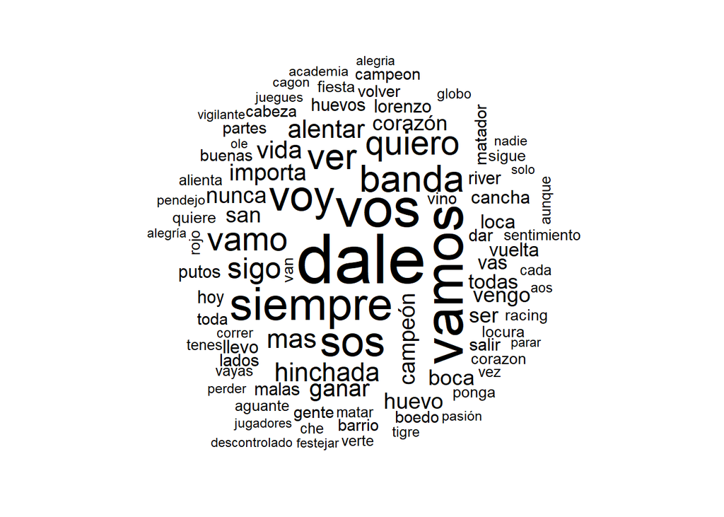

```r
wordcloud(corpus_letras_limpio_c2, min.freq = 50, random.order = FALSE)
```

Intento de análisis de sentimiento

```r
clasif_emo_letras <- classify_emotion(df_letras$text, algorithm = "bayes", prior = 1.0)
```

```r
emocion <- clasif_emo_letras[,7]
emocion[is.na(emocion)] <- "unknown"
table(emocion, useNA = "ifany")
```

```
## emocion
##   anger    fear     joy sadness unknown
##     230       3      94      60     563
```

Intento catalogar por polarización

```r
pol_letras <- classify_polarity(df_letras$text, algorithm = "bayes")
```

Qué quiero hacer

Posible de hacer con las herramientas actuales (más o menos)

- Detectar a quienes hace referencia cada canción. Quiero que por cada línea tenga otra con las referencias.
- En base a eso armar el mapa de relaciones. Asumo que la inmensa mayoría de las referencias a otras hinchadas/clubes son negativas (hay excepciones igual) así que hasta acá puedo avanzar sin meterme con la captura de sentido. Para hacerlo con regex o clasificación simple (ejemplo: al inicio no se si “acade” se refiere a Racing pero al levantar las asociaciones debería salir)

Necesito ayuda

- Captura de sentido. Aunque sea en los términos de positivo/negativo. Pero si es posible para orientarlo a lo que era el problema principal de ver la construcción del yo o del otro.